# χ²検定の基礎と実践 by 戸田梨鈴

### 視覚化

年齢群別に学習スタイルの分布を可視化します。

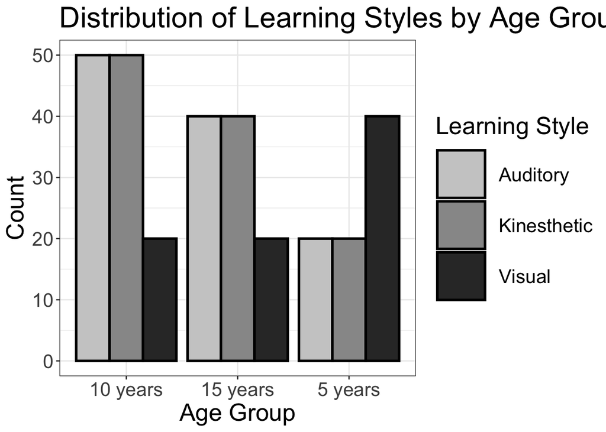

```r
# 必要なパッケージを読み込みます
library(ggplot2)

# バープロットを作成します
ggplot(data_RxC, aes(x=age_group, fill=learning_style, pattern=learning_style)) +
  geom_bar(position="dodge", color="black", size=1) +
  scale_fill_grey(start = 0.8, end = 0.2) +
  theme_bw() +
  theme(
    text = element_text(size=20),
    legend.key.size = unit(1.5, "cm")
  ) +
  labs(x="Age Group", y="Count", fill="Learning Style", pattern="Learning Style",
       title="Distribution of Learning Styles by Age Group")
```

### 結果の解釈

χ²同質性検定の結果から、子供の年齢と学習スタイルの分布に有意な関連性が見られます。具体的には、p値が0.001より小さいことから、帰無仮説（すなわち、全ての年齢群における学習スタイルの分布が等しい）を棄却し、対立仮説（すなわち、最低でも1つの年齢群で学習スタイルの分布が他と異なる）を採択します。

さらに、効果量（Cramér’s V）は0.23と算出され、95%ブートストラップ信頼区間は (0.000, 0.2434) でした。この信頼区間は、同じデータと手法で無数の信頼区間を計算した場合、その95%がこの範囲に真のCramér’s Vを含むことを示しています。しかし、真の値が必ずしもこの範囲に含まれるわけではないことを理解することが重要です。効果量の値は、二つの変数間の統計的な関連性の強さを示す指標で、その値が大きいほど、関連性が強いと解釈されます。この場合、年齢と学習スタイルの間には一定の関連性が存在することが示唆されています。

これらの結果は、子供の学習スタイルが年齢によって変化する可能性があることを示しています。

# 8. 多重比較

多重比較は、一度に複数の仮説検定を実行することを指します。主に、「事前に計画された比較」（Planned Comparisons）と「事後的な比較」（Post-hoc Comparisons）の2つに分類されます。

- **事前に計画された比較（Planned Comparisons）**: これは実験が開始される前に特定の比較が行われることが既に決定している状況を示します。通常、研究者が特定の効果やパターンを予想している際に行います。
- **事後的な比較（Post-hoc Comparisons）**: これはデータ分析の過程で新たに明らかになった結果を詳細に調査するために実施される比較を指します。これらの比較は、元々の仮説には含まれず、新たに得られた観察結果に基づいて行われます。事後的な比較では、多重比較による誤検出のリスクを緩和するため、調整されたp値が一般的に使用されます。

多重比較は、単に偶然による偽陽性（実際には存在しない効果が検出される誤り）のリスクが増えるという問題を孕んでいます。この問題を解消するためには、多重比較補正という手法が用いられ、その中でもいくつかの主要な調整方法が提唱されています。

## 有意水準の調整方法

1. ボンフェローニ補正 (Bonferroni correction): 全ての比較の数でp値を割ることで、偽陽性のリスクを減らします。しかし、厳格すぎるために実際には有意である結果を偽陰性（存在する効果を検出できない誤り）と判断するリスクも増大します。
2. ホルム補正 (Holm correction): ボンフェローニ補正を改良し、全てのp値を小さい順に並べ、それぞれにボンフェローニ補正を適用します。これにより偽陽性のリスクを抑えつつ、偽陰性のリスクも低減します。
3. ベンジャミニ＆ホッホベルク法 (Benjamini & Hochberg method): 偽陽性の「割合」を制御する方法で、全てのp値を小さい順に並べ、それぞれのp値に（その順位/全比較数）*目標FDRを掛けた値を新たなp値とします。
4. チューキーのHSD法 (Tukey’s HSD method): ANOVA（分散分析）後の多重比較に有効で、全てのペア間の比較を行います。

## 独立性の検定と多重比較補正の使用例

この例では、ある幼稚園で男女各100名の子どもたち（合計200名）に、3種類のおもちゃ（A、B、C）の中からどれが一番好きかを選択させ、子どもたちの性別とおもちゃの選択に有意な関連性があるかどうかをχ²検定で評価します。その結果に対して多重比較補正を適用し、性別ごとのおもちゃの選択の違いを詳しく検証します。

```r
# 必要なパッケージを読み込む
library(readr)
library(dplyr)

# データを読み込む
data <- read_csv("20230616_chap4practice_RToda.csv")
head(data)
```

```
## # A tibble: 6 × 3
##      ID gender choice
##   <dbl> <chr>  <chr>
## 1     1 M      A
## 2     2 M      A
## 3     3 M      A
## 4     4 M      A
## 5     5 M      A
## 6     6 M      A
```

```r
# データ型の確認
str(data)
```

```
## spc_tbl_ [200 × 3] (S3: spec_tbl_df/tbl_df/tbl/data.frame)
##  $ ID    : num [1:200] 1 2 3 4 5 6 7 8 9 10 ...
##  $ gender: chr [1:200] "M" "M" "M" "M" ...
##  $ choice: chr [1:200] "A" "A" "A" "A" ...
##  - attr(*, "spec")=
##   .. cols(
##   ..   ID = col_double(),
##   ..   gender = col_character(),
##   ..   choice = col_character()
##   .. )
##  - attr(*, "problems")=<externalptr>
```

```r
# データフレームから性別とおもちゃの選択についてのクロス集計表を作成
contingency_table <- table(data$gender, data$choice)
contingency_table
```

```
##
##      A  B  C
##   F 50 30 20
##   M 10 20 70
```

```r
# χ²独立性検定を実施
chisq_res <- chisq.test(contingency_table)

# p値を取得
p_value <- chisq_res$p.value

# ボンフェローニ補正、ホルム補正、ベンジャミニ＆ホッチベルク補正（BH補正）を適用してp値を補正
bonferroni <- p.adjust(p_value, method = "bonferroni")
holm <- p.adjust(p_value, method = "holm")
BH <- p.adjust(p_value, method = "BH")

# 補正後のp値を表示
data.frame(Bonferroni = bonferroni, Holm = holm, BH = BH)
```

```
##     Bonferroni         Holm           BH
## 1 5.536619e-13 5.536619e-13 5.536619e-13
```

```r
# 性別ごとのおもちゃの選択の違いを詳しく調査するため、ペアワイズのχ²検定を実施
choices <- unique(data$choice)
pairs <- combn(choices, 2)
pairwise_chisq <- sapply(1:ncol(pairs), function(i) {
  subdata <- data %>% filter(choice %in% pairs[,i])
  chisq_res <- chisq.test(table(subdata$gender, subdata$choice))
  chisq_res$p.value
})

# 各ペア間のχ²検定のp値を補正
bonferroni_pairwise <- p.adjust(pairwise_chisq, method = "bonferroni")
holm_pairwise <- p.adjust(pairwise_chisq, method = "holm")
BH_pairwise <- p.adjust(pairwise_chisq, method = "BH")

# 補正後のペアワイズp値を表示
pairwise_df <- data.frame(Pairs = apply(pairs, 2, paste, collapse = " vs "),
                          Bonferroni = bonferroni_pairwise,
                          Holm = holm_pairwise,
                          BH = BH_pairwise)

pairwise_df
```

```
##    Pairs   Bonferroni         Holm           BH
## 1 A vs B 3.509673e-02 1.169891e-02 1.169891e-02
## 2 A vs C 2.051251e-12 2.051251e-12 2.051251e-12
## 3 B vs C 5.460735e-05 3.640490e-05 2.730367e-05
```

これらの結果を通じて、性別ごとのおもちゃの選択の違いを明らかにすることができ、また、その違いが統計的に有意であるかどうかを多重比較補正を用いて評価することができます。

## 一元配置分散分析(ANOVA)とチューキーのHSD法による多重比較の使用例

一元配置分散分析（ANOVA）は、一つ以上の要因が群間での平均値の差異を引き起こすかどうかを評価するための統計的手法です。さらに、チューキーのHSD法を利用することで、具体的な群間の差を明らかにすることができます。ここでは、これらの方法を用いて、特定の介入がスコアにどのような影響を及ぼすかを調査する例を示します。

```r
# 必要なパッケージを読み込む
library(agricolae)

# 再現可能なランダムな結果を得るために乱数シードを設定
set.seed(123)

# データフレームを作成。Intervention列に"A", "B", "C"を、Score列には異なる平均値と標準偏差をもつ正規分布から抽出したスコアを割り当てる
data <- data.frame(
  Intervention = rep(c("A", "B", "C"), each = 50),
  Score = c(rnorm(50, mean = 80, sd = 10),
            rnorm(50, mean = 85, sd = 10),
            rnorm(50, mean = 90, sd = 10))
)
head(data)
```

```
##   Intervention    Score
## 1            A 74.39524
## 2            A 77.69823
## 3            A 95.58708
## 4            A 80.70508
## 5            A 81.29288
## 6            A 97.15065
```

```r
# Intervention列の影響をスコアに対して評価するために一元配置ANOVAを適用する
model <- aov(Score ~ Intervention, data = data)

# ANOVAの結果を表示
summary(model)
```

```
##               Df Sum Sq Mean Sq F value   Pr(>F)
## Intervention   2   1485   742.5   8.387 0.000355 ***
## Residuals    147  13014    88.5
## ---
## Signif. codes:  0 '***' 0.001 '**' 0.01 '*' 0.05 '.' 0.1 ' ' 1
```

```r
# チューキーのHSD法を用いて具体的な群間比較を行う
HSD_result <- HSD.test(model, 'Intervention', group = TRUE)

# 結果を表示
print(HSD_result)
```

```
## $statistics
##    MSerror  Df     Mean       CV      MSD
##   88.52838 147 84.75637 11.10117 4.455503
##
## $parameters
##    test       name.t ntr StudentizedRange alpha
##   Tukey Intervention   3         3.348424  0.05
##
## $means
##      Score      std  r      Min      Max      Q25      Q50      Q75
## A 80.34404 9.258700 50 60.33383 101.6896 74.40683 79.27360 86.98177
## B 86.46408 9.054472 50 61.90831 106.8733 81.38703 86.52579 91.29436
## C 87.46100 9.893339 50 69.46753 111.0011 80.49417 86.95130 92.90086
##
## $comparison
## NULL
##
## $groups
##      Score groups
## C 87.46100      a
## B 86.46408      a
## A 80.34404      b
##
## attr(,"class")
## [1] "group"
```

この例では、ANOVAを使用して教育介入（A、B、C）が学生のスコアに対してどのような影響を及ぼしているかを評価します。その後、チューキーのHSD法を用いて各介入間のスコアの差を明らかにします。ANOVAの結果にかかわらず、チューキーのHSD法は介入効果の具体的な違いを理解するために用いられます。ただし、ANOVAの結果が非有意の場合、その結果を過度に解釈することは避けるべきです。

## マクネマー検定と多重比較補正の使用例

教育介入方法A、B、Cが子供の行動にどれほど影響を及ぼすかを評価します。それぞれの教育介入についてマクネマー検定を行い、得られたp値に対してボンフェローニ補正、ホルム補正、そしてベンジャミニ＆ホッホベルグ法を適用します。これらの補正は、多重比較によって誤って有意な結果と判断されるリスクを軽減するためのものです。

なお、チューキーのHSD法はANOVAの結果に対する多重比較補正として使用される手法で、マクネマー検定に対しては直接適用することはできません。

```r
# 必要なパッケージを読み込み
library(stats)

# 結果の再現性を確保するためのシード設定
set.seed(123)

# 各教育介入方法についてデータ生成
before_A <- sample(c(0, 1), 100, replace = TRUE)
after_A <- sample(c(0, 1), 100, replace = TRUE)
before_B <- sample(c(0, 1), 100, replace = TRUE)
after_B <- sample(c(0, 1), 100, replace = TRUE)
before_C <- sample(c(0, 1), 100, replace = TRUE)
after_C <- sample(c(0, 1), 100, replace = TRUE)

# 各方法についてマクネマー検定の実施
mcnemar_res_A <- mcnemar.test(before_A, after_A)
mcnemar_res_B <- mcnemar.test(before_B, after_B)
mcnemar_res_C <- mcnemar.test(before_C, after_C)

# p値の取得
p_values <- c(mcnemar_res_A$p.value, mcnemar_res_B$p.value, mcnemar_res_C$p.value)

# 各補正法によるp値の調整
bonferroni <- p.adjust(p_values, method = "bonferroni")
holm <- p.adjust(p_values, method = "holm")
BH <- p.adjust(p_values, method = "BH")

# 元のp値と補正後のp値を表示するためのデータフレームを作成
result_df <- data.frame(
  Method = c("A", "B", "C"),
  p_value = p_values,
  p_value_bonferroni = bonferroni,
  p_value_holm = holm,
  p_value_BH = BH
)

# 結果を表示
print(result_df)
```

```
##   Method   p_value p_value_bonferroni p_value_holm p_value_BH
## 1      A 0.1614295          0.4842884    0.4842884  0.4795001
## 2      B 0.4795001          1.0000000    0.7421867  0.4795001
## 3      C 0.3710934          1.0000000    0.7421867  0.4795001
```

これらの結果を通じて、各教育介入方法が子供の行動に与える影響の有意性を複数の補正法に基づいて評価することができます。これにより、個々の教育介入方法の効果をより厳密に解釈することが可能になります。

# 参考ページ:

- [統計学の時間 - パラメトリックとノンパラメトリック](https://bellcurve.jp/statistics/course/1562.html)
- [Study Channel - パラメトリックとノンパラメトリック](https://www.study-channel.com/2015/06/parametric-nonparametric-test.html)
- [日経調査研究所 - χ²検定](https://service.nikkei-r.co.jp/glossary/chi-square-test/)
- [Best Biostatistics - 自由度の理解](https://best-biostatistics.com/contingency/degree-freedom.html)
- [統計学の時間 - χ²適合度検定](https://bellcurve.jp/statistics/course/9494.html)